# tugas kuliah UAS

# Data

## Impor Dataset

```r
library(readr)
df <- read.csv("E:/Atha's Documents/IPB/smt 5/Daging Sapi Murni - Sheet1.csv",
               header = TRUE,
               stringsAsFactors = FALSE)
head(df)
```

```
##   KodeBPS KodeProv NamaProv          KabKot Kategori            Produk  Harga
## 1   11.05       11     Aceh Kab. Aceh Barat  Protein Daging Sapi Murni 143864
## 2   11.05       11     Aceh Kab. Aceh Barat  Protein Daging Sapi Murni 143393
## 3   11.05       11     Aceh Kab. Aceh Barat  Protein Daging Sapi Murni 142000
## 4   11.05       11     Aceh Kab. Aceh Barat  Protein Daging Sapi Murni 159600
## 5   11.05       11     Aceh Kab. Aceh Barat  Protein Daging Sapi Murni 165333
## 6   11.05       11     Aceh Kab. Aceh Barat  Protein Daging Sapi Murni 155185
##   Tahun    Bulan
## 1  2022  Januari
## 2  2022 Februari
## 3  2022    Maret
## 4  2022    April
## 5  2022      Mei
## 6  2022     Juni
```

```r
str(df)
```

```
## 'data.frame':    22708 obs. of  9 variables:
##  $ KodeBPS : num  11.1 11.1 11.1 11.1 11.1 ...
##  $ KodeProv: int  11 11 11 11 11 11 11 11 11 11 ...
##  $ NamaProv: chr  "Aceh" "Aceh" "Aceh" "Aceh" ...
##  $ KabKot  : chr  "Kab. Aceh Barat" "Kab. Aceh Barat" "Kab. Aceh Barat" "Kab. Aceh Barat" ...
##  $ Kategori: chr  "Protein" "Protein" "Protein" "Protein" ...
##  $ Produk  : chr  "Daging Sapi Murni" "Daging Sapi Murni" "Daging Sapi Murni" "Daging Sapi Murni" ...
##  $ Harga   : num  143864 143393 142000 159600 165333 ...
##  $ Tahun   : int  2022 2022 2022 2022 2022 2022 2022 2022 2022 2022 ...
##  $ Bulan   : chr  "Januari" "Februari" "Maret" "April" ...
```

## Cek Missing Value

```r
colSums(is.na(df))
```

```
##  KodeBPS KodeProv NamaProv   KabKot Kategori   Produk    Harga    Tahun
##        0        0      230        0        0        0     1704        0
##    Bulan
##        0
```

Terdapat missing value pada NamaProv sebanyak 230 kolom dan Harga sebanyak 1704 kolom.

## Atasi Missing Value

### NamaProv

Setelah dilihat, provinsi yang NA merupakan Provinsi Kalimantan Utara didapat dari Kabupaten Kota yang tertera pada data, sehingga kolom NA pada NamaProv dengan KodeBPS 65 akan diisi dengan Provinsi Kalimantan Utara.

```r
library(dplyr)
df$NamaProv[df$KodeProv == 65] <- "Kalimantan Utara"

# Cek lagi NA provinsi
sum(is.na(df$NamaProv))
```

```
## [1] 0
```

Missing value nama provinsi sudah tertangani.

### Harga

Missing value harga akan diisi dengan rata-rata harga tiap provinsi.

```r
df <- df %>%
  group_by(KodeProv, NamaProv) %>%
  mutate(
    mean_harga_prov = mean(Harga, na.rm = TRUE),
    Harga_fix = ifelse(is.na(Harga), mean_harga_prov, Harga)
  ) %>%
  ungroup()

# cek lagi NA harga
sum(is.na(df$Harga_fix))
```

```
## [1] 0
```

Missing value harga sudah tertangani.

## Dataset Rata-Rata Harga

```r
df_prov <- df %>%
  group_by(KodeProv, NamaProv) %>%
  summarise(
    Harga_rata_prov = mean(Harga_fix, na.rm = TRUE),
    .groups = "drop"
  )

head(df_prov)
```

```
## # A tibble: 6 × 3
##   KodeProv NamaProv         Harga_rata_prov
##      <int> <chr>                      <dbl>
## 1       11 Aceh                     153804.
## 2       12 Sumatera Utara           135185.
## 3       13 Sumatera Barat           142485.
## 4       14 Riau                     146282.
## 5       15 Jambi                    137027.
## 6       16 Sumatera Selatan         134786.
```

# Menentukan K Optimal

```r
data_km <- df_prov[, "Harga_rata_prov", drop = FALSE]
```

## Elbow Method

Elbow Method digunakan untuk mencari titik penurunan WSS tidak lagi signifikan, sehingga membentuk siku. Metode ini sering dipakai karena visual yang mudah dilihat dan cocok untuk data sederhana.

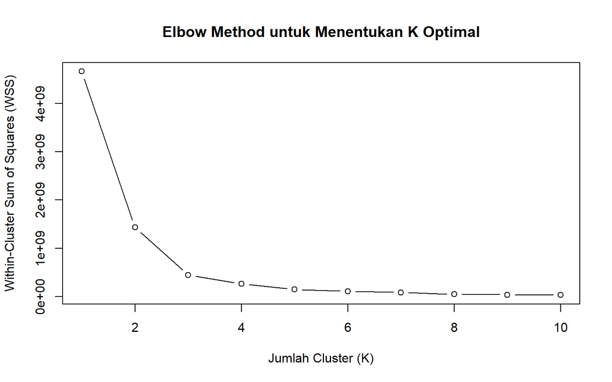

```r
set.seed(123)

max_k <- 10
wss <- numeric(max_k)

for (k in 1:max_k) {
  km_model <- kmeans(data_km, centers = k, nstart = 25)
  wss[k] <- km_model$tot.withinss
}

plot(1:max_k, wss,
     type = "b",
     xlab = "Jumlah Cluster (K)",
     ylab = "Within-Cluster Sum of Squares (WSS)",
     main = "Elbow Method untuk Menentukan K Optimal")
```

Berdasarkan grafik yang diperoleh jumlah cluster optimal adalah K = 3, ditandai dengan perubahan nilai WSS yang signifikan hingga K = 3 dan penurunan yang relatif kecil setelahnya.

## Silhoutte Score

Metode ini merupakan salah satu metode terbaik untuk menentukan K optimal karena keakuratannya dengan konsep mengukur kejelasan cluster dari rentang nilai -1 hingga 1. Semakin besar nilai maka clustering akan semakin bagus. Selanjutnya akan dilakukan perhitungan silhoutte dengan rentang k = 2 sampai 10.

```r
library(cluster)
library(factoextra)
```

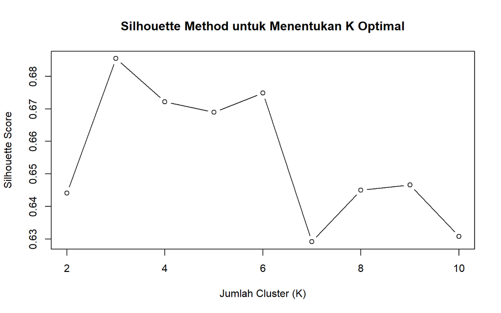

```r
silhouette_scores <- numeric(max_k)

for (k in 2:max_k) {
  km_model <- kmeans(data_km, centers = k, nstart = 25)
  ss <- silhouette(km_model$cluster, dist(data_km))
  silhouette_scores[k] <- mean(ss[, 3])   # rata-rata nilai silhouette
}

# Plot silhouette score
plot(2:max_k, silhouette_scores[2:max_k],
     type = "b",
     xlab = "Jumlah Cluster (K)",
     ylab = "Silhouette Score",
     main = "Silhouette Method untuk Menentukan K Optimal")
```

```r
# tampilkan nilai silhouette secara lengkap
data.frame(
  K = 2:max_k,
  Silhouette = silhouette_scores[2:max_k]
)
```

```
##    K Silhouette
## 1  2  0.6441592
## 2  3  0.6854617
## 3  4  0.6721816
## 4  5  0.6689442
## 5  6  0.6749222
## 6  7  0.6291594
## 7  8  0.6449651
## 8  9  0.6466135
## 9 10  0.6307569
```

Didapatkan hasil nilai tertinggi yaitu 0.6854617 ada pada K = 3 yang menjadikannya K optimal.

# K-Means

Metode K-Means dipilih karena sesuai dengan karakteristik data yang berupa nilai numerik kontinu. Pendekatan ini efektif untuk mengelompokkan provinsi berdasarkan kemiripan harga, sehingga memudahkan identifikasi pola harga antar wilayah. Selain menghasilkan struktur klaster yang sederhana dan mudah diinterpretasikan, K-Means juga merupakan salah satu metode klaster non-hierarki yang umum direkomendasikan dalam analisis multivariat. Pada penelitian ini, variabel yang dianalisis berupa rata-rata harga daging sapi murni per provinsi, sehingga penggunaan metode berbasis jarak seperti K-Means menjadi pilihan yang tepat.

## K-Means dengan K = 3

```r
data_km <- df_prov[, "Harga_rata_prov", drop = FALSE]
```

```r
set.seed(123)
km3 <- kmeans(data_km, centers = 3, nstart = 25)
km3
```

```
## K-means clustering with 3 clusters of sizes 10, 18, 6
##
## Cluster means:
##   Harga_rata_prov
## 1        152192.0
## 2        134768.9
## 3        119548.5
##
## Clustering vector:
##  [1] 1 2 2 1 2 2 2 2 1 1 2 2 2 2 3 2 3 3 3 1 1 1 1 1 2 2 3 2 2 2 3 2 1 2
##
## Within cluster sum of squares by cluster:
## [1] 178484399 165900325  96697044
##  (between_SS / total_SS =  90.5 %)
##
## Available components:
##
## [1] "cluster"      "centers"      "totss"        "withinss"     "tot.withinss"
## [6] "betweenss"    "size"         "iter"         "ifault"
```

```r
df_prov$cluster_raw <- km3$cluster
```

```r
centers <- km3$centers
centers
```

```
##   Harga_rata_prov
## 1        152192.0
## 2        134768.9
## 3        119548.5
```

Terdapat 34 provinsi dengan cluster 1 berisi 10 provinsi, cluster 2 berisi 18 provinsi, dan cluster 3 berisi 6 provinsi. Nilai between-cluster sum of squares sebesar 90.5% menunjukkan bahwa model clustering mampu menjelaskan sebagian besar variasi harga antar provinsi, sehingga pengelompokan dapat dikatakan sangat baik.

## Menyusun Cluster

```r
# Urut dari mahal ke murah
ord <- order(centers[, "Harga_rata_prov"], decreasing = TRUE)
ord
```

```
## [1] 1 2 3
```

## Mapping Cluster

```r
cluster_baru <- rep(NA, nrow(df_prov))

cluster_baru[df_prov$cluster_raw == ord[1]] <- 1   # MAHAL
cluster_baru[df_prov$cluster_raw == ord[2]] <- 2   # SEDANG
cluster_baru[df_prov$cluster_raw == ord[3]] <- 3   # MURAH

df_prov$cluster <- factor(cluster_baru,
                          levels = c(1,2,3),
                          labels = c("Mahal", "Sedang", "Murah"))
head(df_prov)
```

```
## # A tibble: 6 × 5
##   KodeProv NamaProv         Harga_rata_prov cluster_raw cluster
##      <int> <chr>                      <dbl>       <int> <fct>
## 1       11 Aceh                     153804.           1 Mahal
## 2       12 Sumatera Utara           135185.           2 Sedang
## 3       13 Sumatera Barat           142485.           2 Sedang
## 4       14 Riau                     146282.           1 Mahal
## 5       15 Jambi                    137027.           2 Sedang
## 6       16 Sumatera Selatan         134786.           2 Sedang
```

## Ringkasan

```r
library(dplyr)

ringkasan_cluster <- df_prov %>%
  group_by(cluster) %>%
  summarise(
    n_prov = n(),
    mean_harga = mean(Harga_rata_prov),
    min_harga  = min(Harga_rata_prov),
    max_harga  = max(Harga_rata_prov),
    .groups = "drop"
  )

ringkasan_cluster
```

```
## # A tibble: 3 × 5
##   cluster n_prov mean_harga min_harga max_harga
##   <fct>    <int>      <dbl>     <dbl>     <dbl>
## 1 Mahal       10    152192.   144190.   158547.
## 2 Sedang      18    134769.   127799.   142485.
## 3 Murah        6    119549.   114401.   125631.
```

Hasil pengelompokan menggunakan K-Means dengan tiga cluster menunjukkan bahwa provinsi di Indonesia dapat dikelompokkan menjadi tiga kategori berdasarkan rata-rata harga daging sapi murni, yaitu Mahal, Sedang, dan Murah.

1. Cluster “Mahal” terdiri dari 10 provinsi, dengan rata-rata harga sebesar 152.192 rupiah. Harga pada kelompok ini berada pada rentang sekitar 144.189 – 158.547 rupiah, sehingga dapat dikatakan sebagai kelompok dengan tingkat harga tertinggi. Provinsi di cluster ini cenderung memiliki kondisi pasar atau pola distribusi yang menyebabkan harga daging sapi relatif lebih mahal dibanding wilayah lain.
2. Cluster “Sedang” merupakan kelompok dengan jumlah provinsi terbanyak, yaitu 18 provinsi, dan memiliki rata-rata harga sekitar 134.769 rupiah. Rentang harganya berada pada 127.798 – 142.485 rupiah. Kelompok ini mencerminkan wilayah dengan harga daging yang berada pada tingkat menengah dan relatif stabil.
3. Cluster “Murah” terdiri dari 6 provinsi, dengan rata-rata harga terendah yaitu 119.548 rupiah, serta rentang harga 114.401 – 125.631 rupiah. Provinsi dalam cluster ini berada pada segmen harga yang lebih rendah, menunjukkan adanya kondisi pasokan atau faktor ekonomi lokal yang membuat harga daging lebih terjangkau dibandingkan wilayah lain.

Secara keseluruhan, hasil clustering ini menunjukkan bahwa terdapat perbedaan yang cukup jelas antar provinsi dalam hal harga daging sapi murni, dan model K-Means mampu memisahkan provinsi-provinsi tersebut menjadi kelompok harga yang terstruktur dengan baik.

# Boxplot

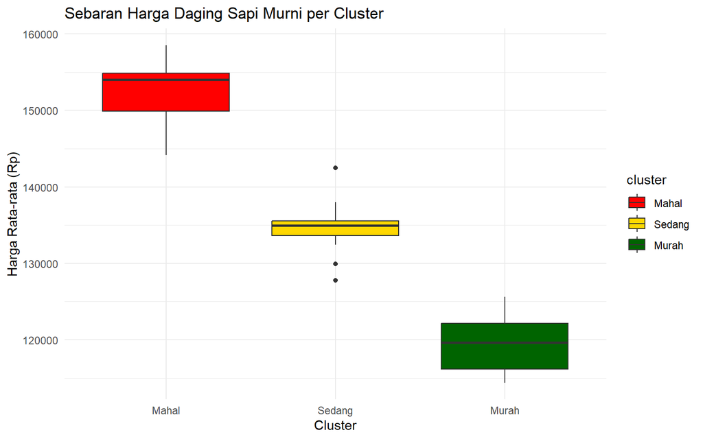

```r
library(ggplot2)

ggplot(df_prov, aes(x = cluster, y = Harga_rata_prov, fill = cluster)) +
  geom_boxplot() +
  scale_fill_manual(values = c("Mahal" = "red",
                               "Sedang" = "gold",
                               "Murah" = "darkgreen")) +
  labs(
    title = "Sebaran Harga Daging Sapi Murni per Cluster",
    x = "Cluster",
    y = "Harga Rata-rata (Rp)"
  ) +
  theme_minimal()
```

1. Cluster Mahal (Merah)

2. Cluster Sedang (Kuning)

3. Cluster Murah (Hijau)

# Barplot

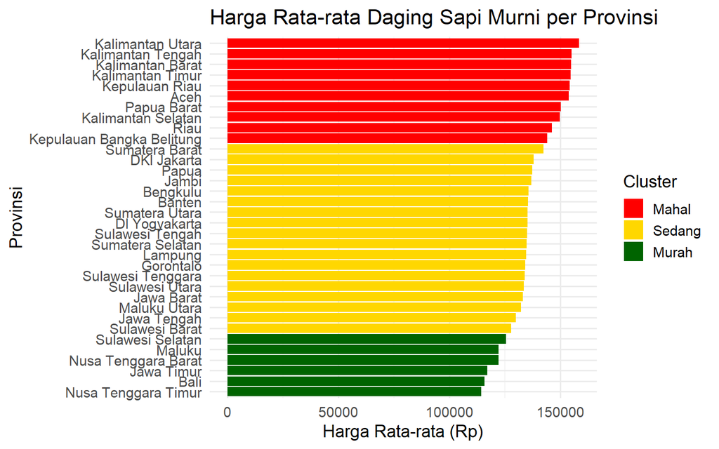

```r
library(ggplot2)

ggplot(df_prov, aes(x = reorder(NamaProv, Harga_rata_prov),
                    y = Harga_rata_prov,
                    fill = cluster)) +
  geom_col() +
  coord_flip() +
  scale_fill_manual(values = c("Mahal" = "red",
                               "Sedang" = "gold",
                               "Murah" = "darkgreen")) +
  labs(
    title = "Harga Rata-rata Daging Sapi Murni per Provinsi",
    x = "Provinsi",
    y = "Harga Rata-rata (Rp)",
    fill = "Cluster"
  ) +
  theme_minimal(base_size = 14)
```

Barplot menunjukkan urutan harga rata-rata daging sapi murni dari provinsi dengan harga tertinggi hingga terendah di Indonesia. Provinsi termahal adalah Kalimantan Utara dan termurah adalah Nusa Tenggara Timur.

# Choropleth Map

```r
library(geodata)
library(sf)
library(dplyr)
```

## Download Provinsi

```r
indo <- gadm(country = "IDN", level = 1, path = ".")
indo_sf <- st_as_sf(indo)
names(indo)
```

```
##  [1] "GID_1"     "GID_0"     "COUNTRY"   "NAME_1"    "VARNAME_1" "NL_NAME_1"
##  [7] "TYPE_1"    "ENGTYPE_1" "CC_1"      "HASC_1"    "ISO_1"
```

## Gabungkan

```r
indo_cluster <- indo_sf %>%
  left_join(df_prov, by = c("NAME_1" = "NamaProv"))
```

## Cek Hasil

```r
sum(is.na(indo_cluster$cluster))
```

```
## [1] 3
```

Masih ada 3 provinsi yang tidak match

## Tangani

```r
indo_cluster %>%
  dplyr::filter(is.na(cluster)) %>%
  dplyr::select(NAME_1, everything())
```

```
## Simple feature collection with 3 features and 15 fields
## Geometry type: MULTIPOLYGON
## Dimension:     XY
## Bounding box:  xmin: 105.108 ymin: -8.20401 xmax: 110.8346 ymax: -1.501757
## Geodetic CRS:  WGS 84
##            NAME_1    GID_1 GID_0   COUNTRY VARNAME_1 NL_NAME_1    TYPE_1
## 1 Bangka Belitung  IDN.3_1   IDN Indonesia      <NA>      <NA> Propinisi
## 2    Jakarta Raya  IDN.7_1   IDN Indonesia      <NA>      <NA> Propinisi
## 3      Yogyakarta IDN.33_1   IDN Indonesia      <NA>      <NA> Propinisi
##   ENGTYPE_1 CC_1 HASC_1 ISO_1 KodeProv Harga_rata_prov cluster_raw cluster
## 1  Province   19  ID.BB  <NA>       NA              NA          NA    <NA>
## 2  Province   31  ID.JK ID-JK       NA              NA          NA    <NA>
## 3  Province   34  ID.YO ID-YO       NA              NA          NA    <NA>
##                         geometry
## 1 MULTIPOLYGON (((107.9614 -3...
## 2 MULTIPOLYGON (((106.8672 -6...
## 3 MULTIPOLYGON (((110.7128 -8...
```

Provinsi yang tidak match namanya adalah Bangka Belitung, Jakarta Raya, dan Yogyakarta sehingga harus disesuaikan.

```r
df_prov$NamaProv[df_prov$KodeProv == 19] <- "Bangka Belitung"
df_prov$NamaProv[df_prov$KodeProv == 31] <- "Jakarta Raya"
df_prov$NamaProv[df_prov$KodeProv == 34] <- "Yogyakarta"
```

```r
unique(df_prov$NamaProv)
```

```
##  [1] "Aceh"                "Sumatera Utara"      "Sumatera Barat"
##  [4] "Riau"                "Jambi"               "Sumatera Selatan"
##  [7] "Bengkulu"            "Lampung"             "Bangka Belitung"
## [10] "Kepulauan Riau"      "Jakarta Raya"        "Jawa Barat"
## [13] "Jawa Tengah"         "Yogyakarta"          "Jawa Timur"
## [16] "Banten"              "Bali"                "Nusa Tenggara Barat"
## [19] "Nusa Tenggara Timur" "Kalimantan Barat"    "Kalimantan Tengah"
## [22] "Kalimantan Selatan"  "Kalimantan Timur"    "Kalimantan Utara"
## [25] "Sulawesi Utara"      "Sulawesi Tengah"     "Sulawesi Selatan"
## [28] "Sulawesi Tenggara"   "Gorontalo"           "Sulawesi Barat"
## [31] "Maluku"              "Maluku Utara"        "Papua Barat"
## [34] "Papua"
```

```r
indo_cluster <- indo_sf %>%
  dplyr::left_join(df_prov, by = c("NAME_1" = "NamaProv"))

sum(is.na(indo_cluster$cluster))
```

```
## [1] 0
```

Nama provinsi sudah match.

## Peta

```r
library(tmap)
```

```r
tmap_mode("plot")
```

```
## ℹ tmap modes "plot" - "view"
## ℹ toggle with `tmap::ttm()`
```

```r
tm_shape(indo_cluster) +
  tm_polygons("cluster",
              palette = c("red", "gold", "darkgreen"),
              title = "Cluster Harga") +
  tm_layout(title = "Peta Cluster Harga Daging Sapi Murni per Provinsi")
```

[output not shown]

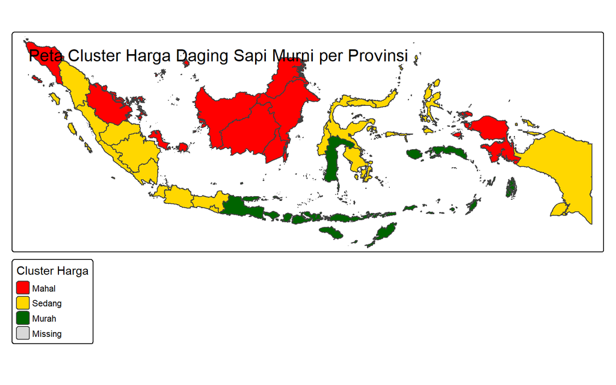

1. Cluster Mahal (Merah)

Pola ini menunjukkan bahwa wilayah yang jauh dari pusat distribusi daging (Jawa) atau memiliki biaya logistik tinggi cenderung memiliki harga yang lebih mahal. Selain itu, beberapa provinsi tersebut bukan sentra produksi sapi, sehingga pasokan harus didatangkan dari luar, mendorong harga menjadi lebih tinggi.

2. Cluster Sedang (Kuning)

Wilayah-wilayah ini memiliki harga yang berada pada tingkat menengah, yang didorong oleh akses distribusi yang relatif lebih baik, rantai pasok yang lebih stabil, dan kedekatan dengan jalur logistik utama.

3. Cluster Murah (Hijau)

Cluster ini mencakup beberapa provinsi di: Nusa Tenggara Barat, Nusa Tenggara Timur, Sulawesi Selatan (sentra sapi potong), Beberapa provinsi timur lain.

Provinsi dalam kelompok ini dikenal sebagai sentra produksi sapi potong, terutama NTB dan Sulawesi Selatan. Tingginya produksi lokal membuat harga di tingkat konsumen lebih rendah dibanding provinsi lain.

Secara keseluruhan, peta cluster menunjukkan bahwa variasi harga daging sapi antar provinsi dipengaruhi oleh pola distribusi geografis, lokasi sentra produksi, dan efisiensi rantai pasok. Wilayah produsen cenderung lebih murah, sedangkan wilayah yang bergantung pada distribusi antar-pulau cenderung lebih mahal.

# Kesimpulan Akhir

Berdasarkan hasil analisis clustering menggunakan metode K-Means dengan K = 3, terlihat bahwa provinsi-provinsi di Indonesia dapat dikelompokkan secara jelas ke dalam tiga kategori harga daging sapi murni, yaitu mahal, sedang, dan murah. Pengelompokan ini mampu menjelaskan 90,5% variasi data sehingga dianggap sangat baik, serta didukung oleh hasil Elbow dan Silhouette yang sama-sama menunjukkan bahwa K = 3 merupakan jumlah cluster optimal. Cluster mahal umumnya berada di wilayah yang jauh dari sentra produksi dan memiliki biaya distribusi lebih tinggi, sementara cluster sedang berada pada wilayah dengan kondisi pasar yang relatif stabil, dan cluster murah didominasi daerah penghasil sapi dengan pasokan lokal yang melimpah. Visualisasi berupa boxplot, barplot, dan choropleth map juga menegaskan perbedaan karakteristik antar cluster, sehingga analisis ini dapat memberikan gambaran yang komprehensif mengenai variasi spasial harga daging sapi murni di Indonesia.